# MAT 400 Final Project

NBA Shot Prediction

Aidan and Liam Greenlee

## DATA EXPLORATION

```r
data <- na.omit(read.csv(file = "data.csv"))
data <- mutate(data,time_remaining = 60*minutes_remaining + seconds_remaining)
```

Here we are cleaning the data a little, combining minutes_remaining and seconds_remaining into one variable as well as omitting NA values.

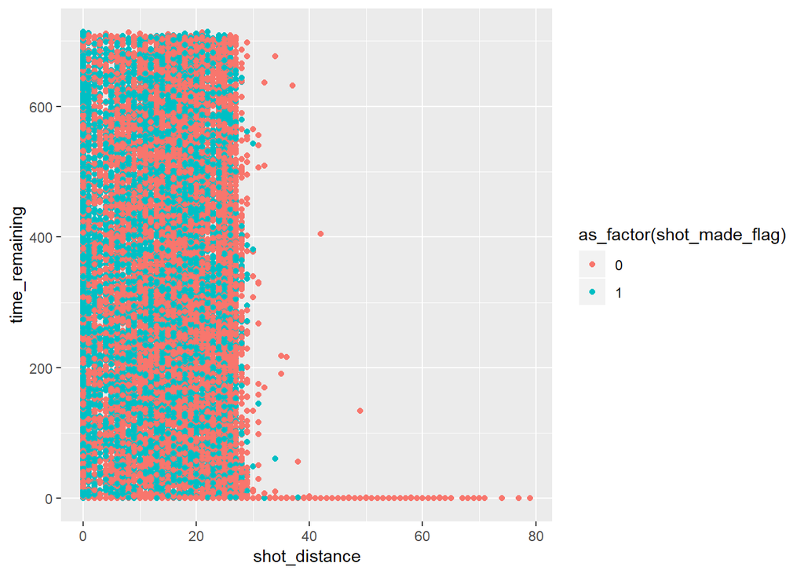

```r
ggplot(data, aes(x=shot_distance, y = time_remaining,color=as_factor(shot_made_flag)))+geom_point()
```

It seems like shot_distance is related to shot_made_flag

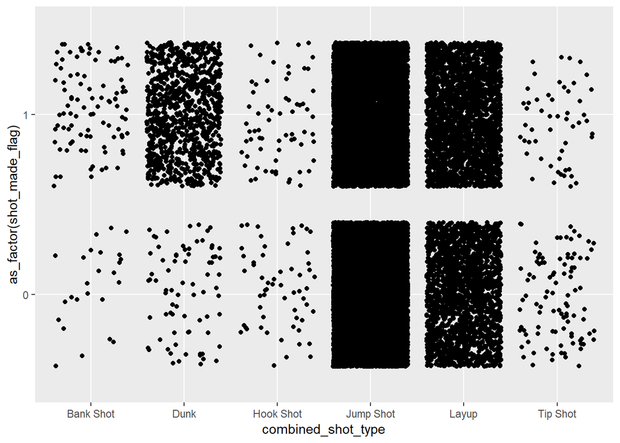

This jitter plot shows that some shot types can be used t determine if the shot was made or missed. (dunks are usually made)

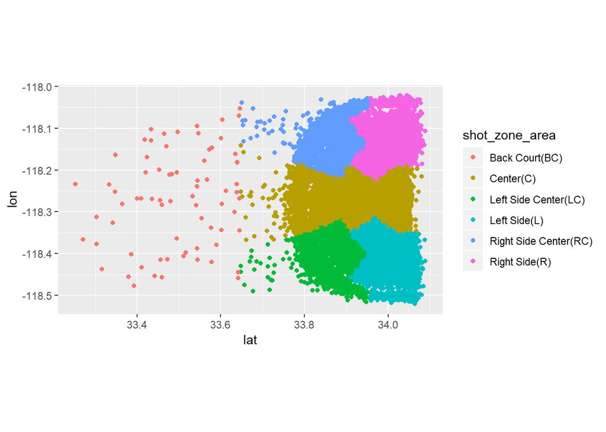

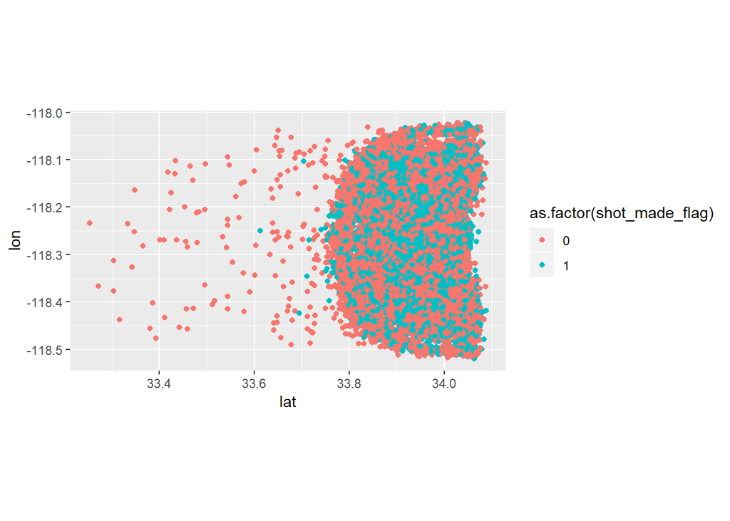

It seems like shots from the back of the court are almost always missed. This is could be a good predictor

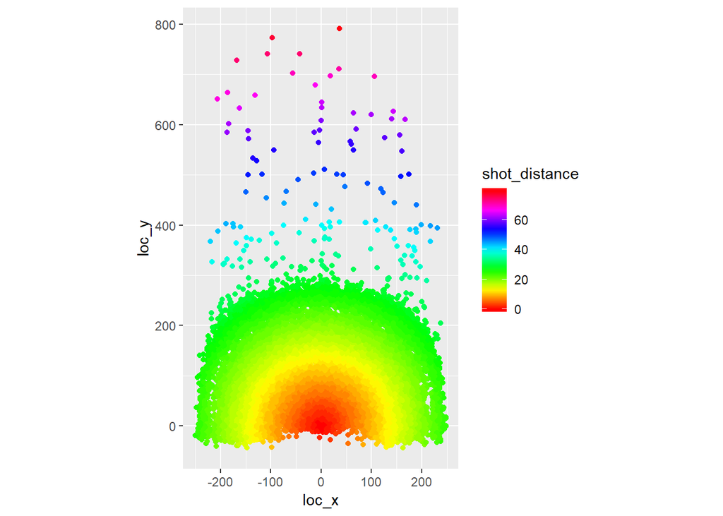

The exploration indicates thate the best predictors could be shot distance, combined shot type, and maybe shot zone area.

## SPLITTING DATA

```r
#data$shot_made_flag <- as.factor(data$shot_made_flag)
dataUsed <- data[,c(2,9,6,7,10,14,15,16,17,18,24,26)]
resample <- initial_split(prop = .7, dataUsed)
test <- testing(resample)
train <- training(resample)
```

The data is split into test and train sets. We omitted some columns that include information from other columns or were not important (game id, shot id, etc.)

## XGBOOST

```r
nfold <- 10
m <- model.matrix(shot_made_flag~., data = train)
m2 <- model.matrix(shot_made_flag~., data = test)
```

An xgboost model is used with 10 fold cross validation.

```r
xgboostmodel <- xgb.cv(data = m, prediction = TRUE, callbacks = list(cb.cv.predict(save_models = TRUE)), label = train$shot_made_flag, nfold = nfold, nrounds = 1000, verbose = 1, objective = "binary:logistic", early_stopping_rounds = 10)
```

```
## Multiple eval metrics are present. Will use test_error for early stopping.
## Will train until test_error hasn't improved in 10 rounds.
##
## Stopping. Best iteration:
```

```r
predserr <- data.frame(numeric(nfold))
xgboostmodel
```

```
## ##### xgb.cv 10-folds
##  iter train_error_mean train_error_std test_error_mean test_error_std
##     1        0.3840646     0.002264158       0.3918709     0.01120348
##     2        0.3824217     0.002384728       0.3912031     0.01345785
##     3        0.3818965     0.001580111       0.3891463     0.01347247
##     4        0.3796789     0.002039162       0.3894246     0.01358251
##     5        0.3785238     0.001703195       0.3901470     0.01281120
##     6        0.3772701     0.002472420       0.3901467     0.01238814
##     7        0.3766955     0.001963422       0.3903694     0.01287385
##     8        0.3753983     0.002190722       0.3905360     0.01309923
##     9        0.3743793     0.002025620       0.3907588     0.01292274
##    10        0.3730758     0.002203679       0.3910368     0.01316766
##    11        0.3722666     0.002247152       0.3916483     0.01364272
##    12        0.3700986     0.002107531       0.3914263     0.01388221
##    13        0.3685482     0.002139315       0.3919820     0.01409010
## Best iteration:
##  iter train_error_mean train_error_std test_error_mean test_error_std
##     3        0.3818965     0.001580111       0.3891463     0.01347247
```

Here, we are performing 10 fold cross validation on xgboost to choose the best model.

```r
for(i in 1:nfold) {
model <- xgb.Booster.complete(xgboostmodel$models[[i]])

test$pred <- predict(model, m2)
test <- test %>% mutate(prediction = ifelse(pred > (1-priorProbability), 1, 0))
test <- test %>% mutate(correct = ifelse(prediction == shot_made_flag, 1, 0))
predserr$numeric.nfold.[i] <- 1-sum(test$correct)/nrow(test)
}

n <- which.min(predserr$numeric.nfold.)
predserr
```

```
##    numeric.nfold.
## 1       0.3874692
## 2       0.3869503
## 3       0.3907122
## 4       0.3864314
## 5       0.3857829
## 6       0.3835776
## 7       0.3869503
## 8       0.3870800
## 9       0.3865612
## 10      0.3866909
```

```r
bestmodel <- xgb.Booster.complete(xgboostmodel$models[[n]])
predserr$numeric.nfold.[n]
```

```
## [1] 0.3835776
```

The misclassification rate of this model is ~ 40%. Some more models will be tested to achieve a lower misclassification rate.

## LOGISTIC REGRESSION

We decided to try logistic regression next.

```r
glm_fit <- glm(shot_made_flag ~ .,
    data = train,
    family = binomial
)
```

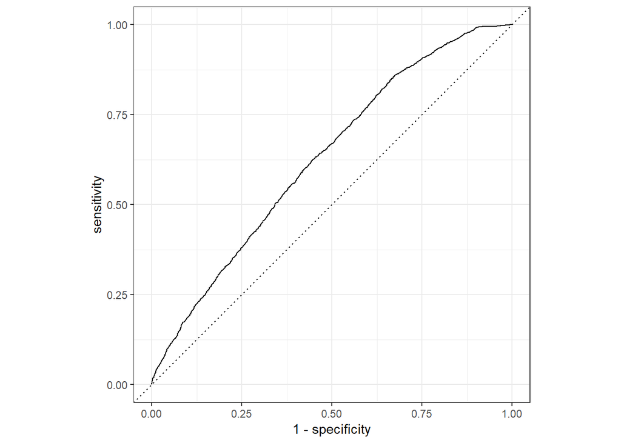

```r
testPred <- test
testPred <- testPred %>% add_predictions(glm_fit) %>% mutate(prob = exp(pred)/ (1 + exp(pred)))

testPred <- testPred %>%
    mutate(shot_made = ifelse(prob > 0.5, 1, 0))

library(tidymodels)
autoplot(roc_curve(testPred, as.factor(shot_made_flag), prob))
```

```r
roc_auc(testPred, as.factor(shot_made_flag), prob)
```

```
## # A tibble: 1 x 3
##   .metric .estimator .estimate
##   <chr>   <chr>          <dbl>
## 1 roc_auc binary         0.629
```

```r
# tidyverse

testPred <- testPred %>% mutate(correct = ifelse(shot_made == shot_made_flag, 1, 0))
1-sum(testPred$correct)/nrow(testPred)
```

```
## [1] 0.3779997
```

This model performed roughly the same as the xgboost model as shown by the ROC curve and the misclassification rate.

## LINEAR DISCRIMINANT ANALYSIS

We discovered the package caret to train data using a bunch of different models, so we decide to try a few out, starting with LDA.

```r
testPred <- test
ldaModel <- train(as.factor(shot_made_flag) ~ ., data=train, method="lda", trControl = trainControl(method = "cv", number = 5))

testPred <- testPred%>%add_predictions(ldaModel)

testPred <- testPred %>% mutate(correct = ifelse(pred == shot_made_flag, 1, 0))
1-sum(testPred$correct)/nrow(testPred)
```

```
## [1] 0.3776106
```

## BAYES GLM

Next we decided to use Bayes GLM from caret.

```r
testPred <- test
bayesmod <- train(as.factor(shot_made_flag) ~ ., data=train, method="bayesglm", trControl = trainControl(method = "cv",number = 5))

testPred <- testPred%>%add_predictions(bayesmod)

testPred <- testPred %>% mutate(correct = ifelse(pred == shot_made_flag, 1, 0))
1-sum(testPred$correct)/nrow(testPred)
```

```
## [1] 0.3777403
```

## NNET

We also decided to a neural network model from caret

```r
testPred <- test
nnetmod <- train(as.factor(shot_made_flag) ~ ., data=train, method="nnet", trControl = trainControl(method = "cv",number = 5))
```

```r
testPred <- testPred%>%add_predictions(nnetmod)

testPred <- testPred %>% mutate(correct = ifelse(pred == shot_made_flag, 1, 0))
1-sum(testPred$correct)/nrow(testPred)
```

```
## [1] 0.3908419
```

## EARTH

Finally, we decided to use earth from caret.

```r
testPred <- test
earthmod <- train(as.factor(shot_made_flag) ~ ., data=train, method="earth", trControl = trainControl(method = "cv",number = 5))
testPred <- testPred%>%add_predictions(earthmod)

testPred <- testPred %>% mutate(correct = ifelse(pred == shot_made_flag, 1, 0))
1-sum(testPred$correct)/nrow(testPred)
```

```
## [1] 0.3791672
```

We found that using all of these led to similar results, around a 39% misclassification rate

## TREE

We tried a tree model

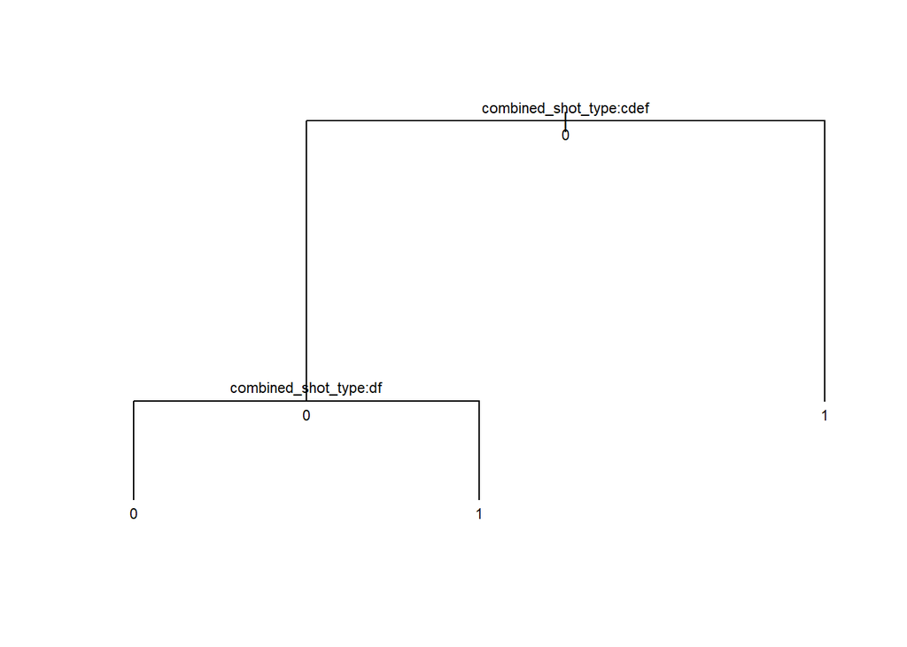

```r
testPred <- test
train$shot_made_flag <- as_factor(train$shot_made_flag)
treefit <- tree(data = train, shot_made_flag ~ .  -opponent, method = "misclass")
plot(treefit)
text(treefit, all = TRUE, cex = .7)
```

This plot shows the tree. There are not many nodes, which we thought was unusual.

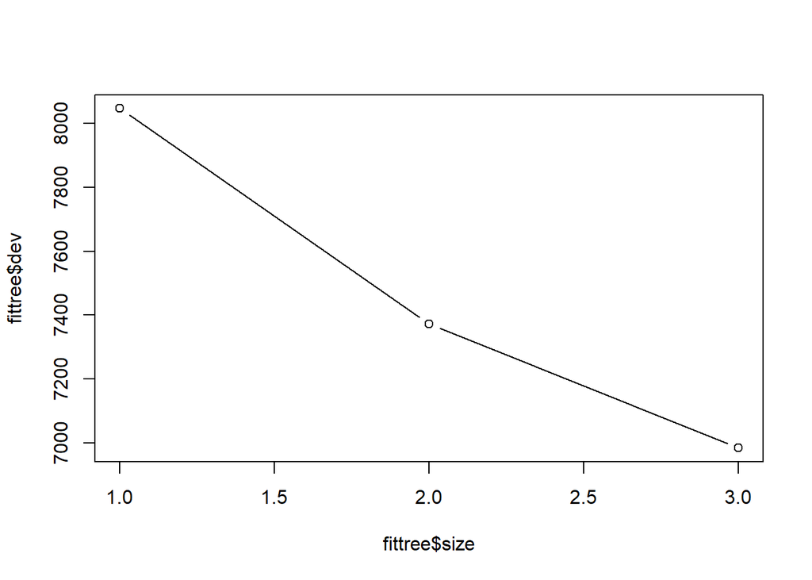

```r
fittree <- cv.tree(treefit, method = "misclass")
plot(fittree$size, fittree$dev, type = "b")
```

This graph shows the best size for the tree, which is used for the pruning.

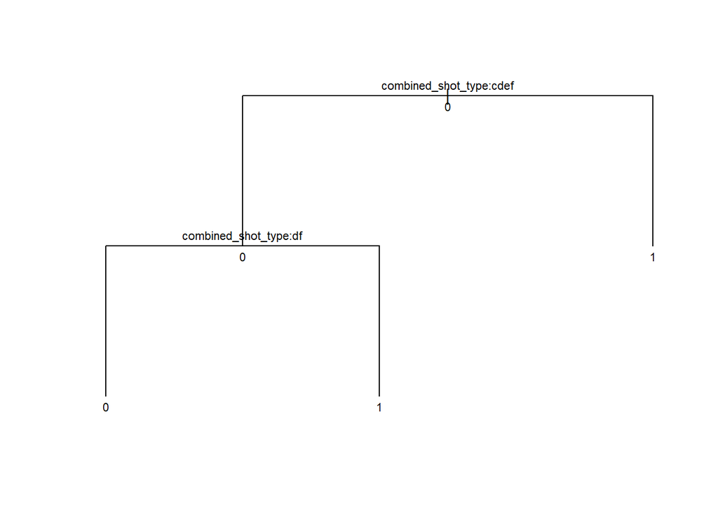

```r
prune_fit <- prune.misclass(treefit, best = 3)
plot(prune_fit, type = "uniform")
text(prune_fit, all = TRUE, cex = .7)
```

```r
testPred %>% modelr::add_predictions(prune_fit, type = "class") %>%
    accuracy(as.factor(shot_made_flag), pred)
```

```
## # A tibble: 1 x 3
##   .metric  .estimator .estimate
##   <chr>    <chr>          <dbl>
## 1 accuracy binary         0.623
```

The pruned tree looks the same as the original fit. The tree model yields a similar misclassification rate to other models.